# Resilience scale reliability and factor analysis

Antonia Wadley, Duncan Mitchell, and Peter Kamerman

20 August 2015

# Overview

Factor analysis and internal consistency assessment of isiZulu translation of the Connor-Davidson Resilience Scale (CD-RISC) [2], and the Resilience Scale (RS) [4] in 154 isiZulu-speaking South Africans. The study took place in 2014/2015, at the Virology Clinic, Charlotte Maxeke Johannesburg Academic Hospital, South Africa. The questionnaires were administered to participants by Mrs Florence Mtsweni and Mrs Thobeka Bucwa. All participants had given written informed consent (Human Ethics Research Committee, University of the Witwatersrand, South Africa: MXXXXX), and no personal identifying information is provided here.

Details of the factor analyses results from the original validation studies for the CD-RISC and RS are shown in the table below.

| Questionnaire | Measurement scale | Analysis | No. of factors | Names given to factors | Questions loading onto each factor |
| --- | --- | --- | --- | --- | --- |
| CD-RISC | Ordinal 1-5 scale anchored at *‘not true at all’* to *‘true nearly all the time’* | Exploratory Factor Analysis with ORTHOMAX rotation | 5 | **Factor 1:** Personal competence **Factor 2:** Trusting one’s instincts **Factor 3:** Positive acceptance of change **Factor 4:** Control **Factor 5:** Spiritual influences | **Factor 1:** 10, 11, 12, 16, 17, 23, 24, 25 **Factor 2:** 6, 7, 14, 15, 18, 19, 20 **Factor 3:** 1, 4, 5, 2, 8 **Factor 4:** 13, 21, 22 **Factor 5:** 3,9 |
| Resilience Scale | Ordinal 1-7 scale anchored at *‘strongly disagree’* to *‘strongly agree’* | Principal Component Analysis with OBLIMIN rotation and Kaiser normalisation | 2 | **Factor 1:** Personal competence **Factor 2:** Acceptance of self and life | **Factor 1:** 1, 2, 3, 4, 5, 6, 9, 10,13, 14, 15, 17, 18, 19, 20, 23, 24 **Factor 2:** 7, 8, 11, 12, 16, 21, 22, 25 |

# Data analysis

## Miscellaneous

### R version used

- R version 3.1.2 (2014-10-31) – “Pumpkin Helmet” [5]

### Packages used

- library(*pander*) [3]
- library(*knitr*) [10–12]
- library(*dplyr*) [9]
- library(*tidyr*) [8]
- library(*ggplot2*) [7]
- library(*psych*) [6]
- library(*GPArotation*) [1]

## CD-RISC

### Code key

| Label | Key |
| --- | --- |
| Q1 | I am able to adapt when changes occur |
| Q2 | I have at least one close and secure relationship that helps me when I’m stressed |
| Q3 | When there are no clear solutions to my problems, sometimes fate or God can help |
| Q4 | I can deal with whatever comes my way |
| Q5 | Past successes give me confidence in dealing with new challenges and difficulties |
| Q6 | I try and see the humorous side of things when I’m faced with problems |
| Q7 | Having to cope with stress can make me stronger |
| Q8 | I tend to bounce back after illness, injury or other hardships |
| Q9 | Good or bad, I believe that most things happen for a reason |
| Q10 | I give my best effort no matter what the outcome may be |
| Q11 | I believe I can achieve my goals, even if there are obstacles |
| Q12 | Even when things look hopeless, I don’t give up |
| Q13 | During times of stress/crisis, I know where to turn for help |
| Q14 | Under pressure, I stay focused and think clearly |
| Q15 | I prefer to take the lead in solving problems rather than letting others make all the decisions |
| Q16 | I am not easily discouraged by failure |
| Q17 | I think of myself as a strong person when dealing with life’s challenges and difficulties |
| Q18 | I can make unpopular or difficult decisions that affect other people, if it is necessary |
| Q19 | I am able to handle unpleasant or painful feelings like sadness, fear, and anger |
| Q20 | In dealing with life’s problems, sometimes you have to act on a hunch without knowing why |
| Q21 | I have a strong sense of purpose in life |
| Q22 | I feel in control of my life |
| Q23 | I like challenges |
| Q24 | I work to attain my goals no matter what roadblocks I encounter along the way |
| Q25 | I take pride in my achievements |

### Import data

```r
# Read csv
data.1 <- read.csv("cd.risc.csv", header = T)
```

### Inspect and clean data

```r
# Convert to dplyr object
data.1 <- tbl_df(data.1)

# Inspect the data
head(data.1)
```

```
## Source: local data frame [6 x 26]
##
##   ID Q1 Q2 Q3 Q4 Q5 Q6 Q7 Q8 Q9 Q10 Q11 Q12 Q13 Q14 Q15 Q16 Q17 Q18 Q19
## 1  1  2  0  4  4  4  4  4  4  4   4   3   4   4   4   4   4   4   4   4
## 2  2  2  4  4  2  4  2  0  2  0   2   2   3   4   2   2   3   2   2   3
## 3  3  4  4  4  4  4  3  2  4  4   4   4   4   4   4   4   4   4   0   4
## 4  4  4  4  4  3  3  3  4  4  4   3   1   4   0   2   2   4   2   4   4
## 5  5  2  2  4  2  4  2  2  4  2   4   4   4   4   2   2   4   4   2   2
## 6  6  2  2  4  0  1  3  3  2  4   3   2   3   2   2   2   4   3   1   0
## Variables not shown: Q20 (int), Q21 (int), Q22 (int), Q23 (int), Q24
##   (int), Q25 (int)
```

```r
tail(data.1)
```

```
## Source: local data frame [6 x 26]
##
##    ID Q1 Q2 Q3 Q4 Q5 Q6 Q7 Q8 Q9 Q10 Q11 Q12 Q13 Q14 Q15 Q16 Q17 Q18 Q19
## 1 187  2  0  4  4  4  0  1  4  4   4   4   4   4   0   4   4   4   4   4
## 2 191  3  2  4  4  4  2  0  1  4   4   4   4   2   4   4   4   4   0   4
## 3 193  3  3  4  4  4  4  4  4  3   3   4   4   3   3   4   4   3   2   4
## 4 195  2  0  4  3  2  3  0  4  4   4   2   3   2   4   3   4   4   0   3
## 5 196  2  0  4  4  4  2  0  4  4   4   4   4   4   0   4   4   4   4   4
## 6 197  2  4  4  4  4  4  0  4  4   4   4   4   0   2   2   3   4   0   3
## Variables not shown: Q20 (int), Q21 (int), Q22 (int), Q23 (int), Q24
##   (int), Q25 (int)
```

```r
str(data.1)
```

```
## Classes 'tbl_df', 'tbl' and 'data.frame':    154 obs. of  26 variables:
##  $ ID : int  1 2 3 4 5 6 7 8 9 10 ...
##  $ Q1 : int  2 2 4 4 2 2 2 2 2 4 ...
##  $ Q2 : int  0 4 4 4 2 2 4 3 2 4 ...
##  $ Q3 : int  4 4 4 4 4 4 4 4 2 4 ...
##  $ Q4 : int  4 2 4 3 2 0 4 3 2 4 ...
##  $ Q5 : int  4 4 4 3 4 1 4 2 4 4 ...
##  $ Q6 : int  4 2 3 3 2 3 1 3 2 4 ...
##  $ Q7 : int  4 0 2 4 2 3 0 0 2 4 ...
##  $ Q8 : int  4 2 4 4 4 2 2 0 2 4 ...
##  $ Q9 : int  4 0 4 4 2 4 2 2 4 4 ...
##  $ Q10: int  4 2 4 3 4 3 4 3 4 4 ...
##  $ Q11: int  3 2 4 1 4 2 4 3 4 4 ...
##  $ Q12: int  4 3 4 4 4 3 4 1 4 4 ...
##  $ Q13: int  4 4 4 0 4 2 4 2 2 4 ...
##  $ Q14: int  4 2 4 2 2 2 4 2 4 4 ...
##  $ Q15: int  4 2 4 2 2 2 2 3 4 4 ...
##  $ Q16: int  4 3 4 4 4 4 4 2 4 4 ...
##  $ Q17: int  4 2 4 2 4 3 4 3 4 4 ...
##  $ Q18: int  4 2 0 4 2 1 2 2 4 2 ...
##  $ Q19: int  4 3 4 4 2 0 2 1 4 4 ...
##  $ Q20: int  4 2 0 3 2 2 4 3 2 4 ...
##  $ Q21: int  4 4 4 4 4 2 4 1 4 4 ...
##  $ Q22: int  4 2 4 4 4 3 4 1 2 4 ...
##  $ Q23: int  4 0 4 3 4 3 2 1 4 4 ...
##  $ Q24: int  4 2 4 4 4 3 4 3 4 4 ...
##  $ Q25: int  4 3 4 4 4 4 4 4 2 4 ...
```

```r
# Convert data classes as nessesary
data.1$ID <- factor(data.1$ID)
str(data.1$ID)
```

```
##  Factor w/ 154 levels "1","2","3","4",..: 1 2 3 4 5 6 7 8 9 10 ...
```

### Internal consistency

**Use polychoric correlation matrix throughout because data are ordinal integers, and therefore Pearson’s correlation matrix does not apply**

```r
# Remove ID column
data.1.1 <- data.1[, -1]

# Look at the data
kable(describe(data.1.1))
```

|  | vars | n | mean | sd | median | trimmed | mad | min | max | range | skew | kurtosis | se |
| --- | --- | --- | --- | --- | --- | --- | --- | --- | --- | --- | --- | --- | --- |
| Q1 | 1 | 154 | 2.772727 | 0.9803476 | 3 | 2.814516 | 1.4826 | 0 | 4 | 4 | -0.1994095 | -0.7313042 | 0.0789987 |
| Q2 | 2 | 154 | 2.876623 | 1.3543825 | 3 | 3.088710 | 1.4826 | 0 | 4 | 4 | -0.9378774 | -0.3904256 | 0.1091393 |
| Q3 | 3 | 154 | 3.733766 | 0.7324612 | 4 | 3.943548 | 0.0000 | 0 | 4 | 4 | -3.0162455 | 9.3388201 | 0.0590234 |
| Q4 | 4 | 154 | 3.136364 | 1.0910700 | 4 | 3.298387 | 0.0000 | 0 | 4 | 4 | -0.9893935 | 0.0085065 | 0.0879209 |
| Q5 | 5 | 154 | 3.279221 | 0.9934212 | 4 | 3.443548 | 0.0000 | 0 | 4 | 4 | -1.2904579 | 0.9805925 | 0.0800522 |
| Q6 | 6 | 154 | 2.746753 | 1.1857635 | 3 | 2.887097 | 1.4826 | 0 | 4 | 4 | -0.6740373 | -0.3516725 | 0.0955515 |
| Q7 | 7 | 154 | 2.019480 | 1.5188178 | 2 | 2.024193 | 2.2239 | 0 | 4 | 4 | 0.0229307 | -1.4438701 | 0.1223898 |
| Q8 | 8 | 154 | 3.012987 | 1.1935941 | 4 | 3.185484 | 0.0000 | 0 | 4 | 4 | -0.8954449 | -0.3447204 | 0.0961826 |
| Q9 | 9 | 154 | 3.448052 | 0.9005605 | 4 | 3.629032 | 0.0000 | 0 | 4 | 4 | -1.7927449 | 3.0490401 | 0.0725692 |
| Q10 | 10 | 154 | 3.285714 | 0.9197491 | 4 | 3.427419 | 0.0000 | 0 | 4 | 4 | -1.1394656 | 0.5353928 | 0.0741155 |
| Q11 | 11 | 154 | 3.324675 | 0.9066430 | 4 | 3.467742 | 0.0000 | 0 | 4 | 4 | -1.2003997 | 0.6871206 | 0.0730594 |
| Q12 | 12 | 154 | 3.519480 | 0.8340842 | 4 | 3.701613 | 0.0000 | 0 | 4 | 4 | -1.8069500 | 2.7954622 | 0.0672124 |
| Q13 | 13 | 154 | 2.935065 | 1.2918818 | 4 | 3.137097 | 0.0000 | 0 | 4 | 4 | -0.8921068 | -0.3596341 | 0.1041028 |
| Q14 | 14 | 154 | 2.694805 | 1.2489364 | 3 | 2.822581 | 1.4826 | 0 | 4 | 4 | -0.5336838 | -0.7720070 | 0.1006422 |
| Q15 | 15 | 154 | 3.376623 | 0.8637804 | 4 | 3.491935 | 0.0000 | 1 | 4 | 3 | -0.9794281 | -0.4549191 | 0.0696054 |
| Q16 | 16 | 154 | 3.409091 | 0.9118941 | 4 | 3.588710 | 0.0000 | 0 | 4 | 4 | -1.5044686 | 1.4739548 | 0.0734825 |
| Q17 | 17 | 154 | 3.383117 | 0.9372331 | 4 | 3.556452 | 0.0000 | 0 | 4 | 4 | -1.4838509 | 1.5412965 | 0.0755244 |
| Q18 | 18 | 154 | 2.006493 | 1.4796959 | 2 | 2.008065 | 1.4826 | 0 | 4 | 4 | -0.0110755 | -1.3433274 | 0.1192373 |
| Q19 | 19 | 154 | 3.071429 | 1.1208490 | 3 | 3.250000 | 1.4826 | 0 | 4 | 4 | -0.9972035 | 0.0482329 | 0.0903206 |
| Q20 | 20 | 154 | 2.935065 | 1.0766404 | 3 | 3.088710 | 1.4826 | 0 | 4 | 4 | -0.9647129 | 0.4474708 | 0.0867582 |
| Q21 | 21 | 154 | 3.623377 | 0.7504066 | 4 | 3.798387 | 0.0000 | 1 | 4 | 3 | -1.8506190 | 2.2865127 | 0.0604695 |
| Q22 | 22 | 154 | 3.558442 | 0.8478116 | 4 | 3.758065 | 0.0000 | 0 | 4 | 4 | -1.9719607 | 3.2167447 | 0.0683186 |
| Q23 | 23 | 154 | 3.266234 | 1.0968893 | 4 | 3.491935 | 0.0000 | 0 | 4 | 4 | -1.4806859 | 1.3260515 | 0.0883899 |
| Q24 | 24 | 154 | 3.668831 | 0.6769327 | 4 | 3.814516 | 0.0000 | 0 | 4 | 4 | -2.5068251 | 7.4022722 | 0.0545488 |
| Q25 | 25 | 154 | 3.727273 | 0.6290643 | 4 | 3.870968 | 0.0000 | 0 | 4 | 4 | -2.8521252 | 9.8069358 | 0.0506914 |

```r
# Generate and view polychoric correlation matrix
pc.1 <- polychoric(data.1.1)
```

```
## The items do not have an equal number of response alternatives, global set to FALSE
```

```r
# Generate internal consistency coefficient alpha
pander(summary(alpha(pc.1$rho)), style = "rmarkdown", justify = "left", round = 2,
    caption = "CD-RISC: internal consistency")
```

Reliability analysis  
raw_alpha std.alpha G6(smc) average_r S/N 0.9 0.9 0.93 0.28 9.5

CD-RISC: internal consistency

| raw_alpha | std.alpha | G6(smc) | average_r | S/N |
| --- | --- | --- | --- | --- |
| 0.9 | 0.9 | 0.93 | 0.28 | 9.52 |

### Factor analysis - initial

```
## The items do not have an equal number of response alternatives, global set to FALSE
```

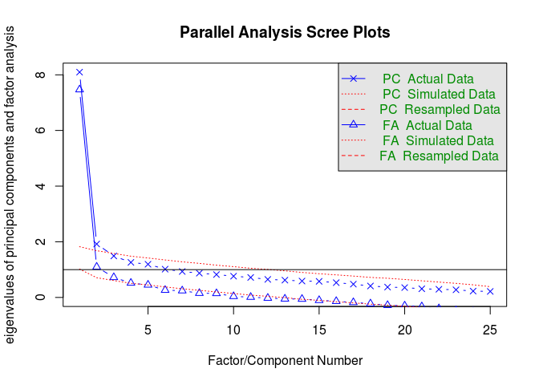

[output not shown]

```r
# Print parallel plots Kaiser dictum: use number of PCA factors above 1 PCA
# line
fa.parallel(data.1.1, fm = "ml", cor = "poly")
```

```r
# Complete factor analysis - use maximum liklihood (ml) method Start with
# nfactor=3 based on fa.parallel plot Thereafter repeat analysis using 2 and
# 4 factors Test oblique rotation first (Oblimin) Oblimin: 3 factor
fa.1f3o <- fa.poly(data.1.1, nfactors = 3, rotate = "oblimin", fm = "ml", global = F)
```

```
## The items do not have an equal number of response alternatives, global set to FALSE
```

```r
### Oblimin: 4 factor
fa.1f4o <- fa.poly(data.1.1, nfactors = 4, rotate = "oblimin", fm = "ml", global = F)
```

```
## The items do not have an equal number of response alternatives, global set to FALSE
```

```r
### Oblimin: 2 factor
fa.1f2o <- fa.poly(data.1.1, nfactors = 2, rotate = "oblimin", fm = "ml", global = F)
```

```
## The items do not have an equal number of response alternatives, global set to FALSE
```

```r
# Interpret Oblimin: 3 factor
fa.diagram(fa.1f3o, cut = 0, digits = 3, labels = as.list(cdr.names))
```

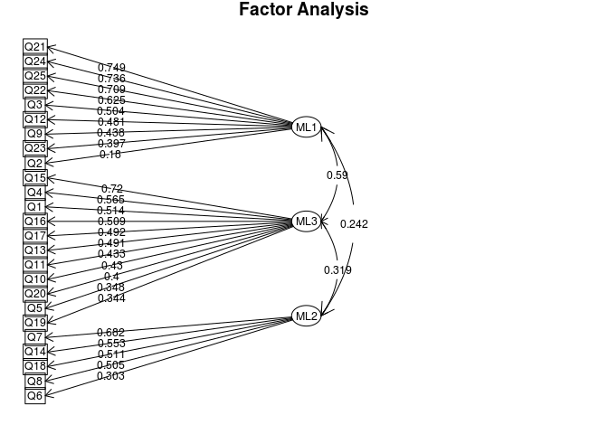

```r
print(fa.1f3o, cut = 0, digits = 3)
```

```
## Factor Analysis using method =  ml
## Call: fa.poly(x = data.1.1, nfactors = 3, rotate = "oblimin", fm = "ml",
##     global = F)
## Standardized loadings (pattern matrix) based upon correlation matrix
##        ML1    ML3    ML2     h2    u2  com
## Q1  -0.015  0.514  0.065 0.2808 0.719 1.03
## Q2   0.180  0.050  0.164 0.0918 0.908 2.15
## Q3   0.504  0.031 -0.065 0.2603 0.740 1.04
## Q4   0.068  0.565  0.004 0.3713 0.629 1.03
## Q5   0.325  0.348  0.139 0.4316 0.568 2.31
## Q6   0.275 -0.074  0.303 0.1750 0.825 2.11
## Q7  -0.213  0.130  0.682 0.4811 0.519 1.27
## Q8   0.199  0.071  0.505 0.3877 0.612 1.35
## Q9   0.438  0.157  0.137 0.3595 0.640 1.47
## Q10  0.229  0.430  0.142 0.4284 0.572 1.77
## Q11  0.254  0.433  0.082 0.4217 0.578 1.70
## Q12  0.481  0.292  0.043 0.5020 0.498 1.67
## Q13  0.011  0.491  0.242 0.3825 0.617 1.46
## Q14  0.283 -0.257  0.553 0.3510 0.649 1.96
## Q15 -0.026  0.720 -0.083 0.4663 0.534 1.03
## Q16  0.209  0.509 -0.016 0.4213 0.579 1.33
## Q17  0.215  0.492  0.144 0.4929 0.507 1.56
## Q18 -0.154  0.115  0.511 0.2763 0.724 1.29
## Q19  0.132  0.344  0.176 0.2692 0.731 1.82
## Q20  0.038  0.400  0.032 0.1886 0.811 1.03
## Q21  0.749 -0.006 -0.036 0.5449 0.455 1.00
## Q22  0.625  0.210 -0.023 0.5802 0.420 1.23
## Q23  0.397  0.358  0.022 0.4629 0.537 1.99
## Q24  0.736  0.071  0.000 0.6080 0.392 1.02
## Q25  0.709 -0.059  0.002 0.4582 0.542 1.01
##
##                         ML1   ML3   ML2
## SS loadings           4.131 3.745 1.817
## Proportion Var        0.165 0.150 0.073
## Cumulative Var        0.165 0.315 0.388
## Proportion Explained  0.426 0.386 0.187
## Cumulative Proportion 0.426 0.813 1.000
##
##  With factor correlations of
##       ML1   ML3   ML2
```

[output cut: 10 more lines]

```
## The root mean square of the residuals (RMSR) is  0.053
## The df corrected root mean square of the residuals is  0.061
##
## The harmonic number of observations is  154 with the empirical chi square  264.365  with prob <  0.0494
## The total number of observations was  154  with MLE Chi Square =  338.816  with prob <  2.58e-06
##
## Tucker Lewis Index of factoring reliability =  0.8757
## RMSEA index =  0.0628  and the 90 % confidence intervals are  0.0432 0.0684
## BIC =  -809.609
## Fit based upon off diagonal values = 0.97
## Measures of factor score adequacy
##                                                  ML1   ML3   ML2
## Correlation of scores with factors             0.938 0.921 0.854
## Multiple R square of scores with factors       0.879 0.848 0.729
## Minimum correlation of possible factor scores  0.758 0.696 0.458
```

```r
## Oblimin: 4 factor
fa.diagram(fa.1f4o, cut = 0, digits = 3, labels = as.list(cdr.names))
```

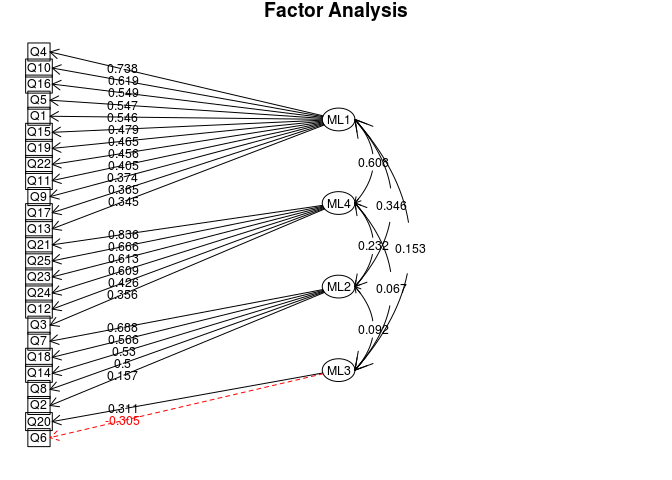

```r
print(fa.1f4o, cut = 0, digits = 3)
```

```
## Factor Analysis using method =  ml
## Call: fa.poly(x = data.1.1, nfactors = 4, rotate = "oblimin", fm = "ml",
##     global = F)
## Standardized loadings (pattern matrix) based upon correlation matrix
##        ML1    ML4    ML2    ML3     h2    u2  com
## Q1   0.546 -0.086  0.053  0.089 0.2919 0.708 1.12
## Q2   0.100  0.147  0.157 -0.057 0.0942 0.906 2.99
## Q3   0.242  0.356 -0.102 -0.156 0.2757 0.724 2.39
## Q4   0.738 -0.111 -0.039  0.016 0.4441 0.556 1.05
## Q5   0.547  0.147  0.113 -0.093 0.4711 0.529 1.30
## Q6   0.218  0.070  0.255 -0.305 0.2388 0.761 2.93
## Q7   0.057 -0.173  0.688  0.030 0.4708 0.529 1.14
## Q8   0.125  0.149  0.500 -0.073 0.3831 0.617 1.36
## Q9   0.374  0.273  0.102 -0.165 0.3879 0.612 2.45
## Q10  0.619  0.048  0.108 -0.045 0.4746 0.525 1.08
## Q11  0.405  0.237  0.098  0.131 0.4247 0.575 2.00
## Q12  0.341  0.426  0.049  0.016 0.5001 0.500 1.94
## Q13  0.345  0.064  0.282  0.221 0.3913 0.609 2.77
## Q14 -0.113  0.200  0.530 -0.211 0.3390 0.661 1.73
## Q15  0.479  0.086 -0.034  0.398 0.4937 0.506 2.02
## Q16  0.549  0.133 -0.017  0.081 0.4213 0.579 1.16
## Q17  0.365  0.262  0.181  0.230 0.5128 0.487 3.14
## Q18 -0.062 -0.048  0.566  0.125 0.3185 0.682 1.14
## Q19  0.465  0.010  0.153 -0.030 0.2909 0.709 1.23
## Q20  0.164  0.172  0.089  0.311 0.2410 0.759 2.36
## Q21 -0.075  0.836 -0.006  0.034 0.6310 0.369 1.02
## Q22  0.456  0.436 -0.061 -0.153 0.6082 0.392 2.26
## Q23  0.052  0.613  0.097  0.372 0.6398 0.360 1.73
## Q24  0.240  0.609 -0.013 -0.103 0.5950 0.405 1.37
## Q25  0.020  0.666  0.010 -0.078 0.4624 0.538 1.03
##
##                         ML1   ML4   ML2   ML3
## SS loadings           4.218 3.492 1.855 0.836
## Proportion Var        0.169 0.140 0.074 0.033
## Cumulative Var        0.169 0.308 0.383 0.416
## Proportion Explained  0.406 0.336 0.178 0.080
## Cumulative Proportion 0.406 0.741 0.920 1.000
##
##  With factor correlations of
##       ML1   ML4   ML2   ML3
```

[output cut: 11 more lines]

```
## The root mean square of the residuals (RMSR) is  0.047
## The df corrected root mean square of the residuals is  0.057
##
## The harmonic number of observations is  154 with the empirical chi square  208.152  with prob <  0.445
## The total number of observations was  154  with MLE Chi Square =  288.04  with prob <  0.000139
##
## Tucker Lewis Index of factoring reliability =  0.8975
## RMSEA index =  0.058  and the 90 % confidence intervals are  0.0361 0.0642
## BIC =  -749.572
## Fit based upon off diagonal values = 0.976
## Measures of factor score adequacy
##                                                  ML1   ML4   ML2   ML3
## Correlation of scores with factors             0.933 0.934 0.858 0.775
## Multiple R square of scores with factors       0.870 0.872 0.737 0.600
## Minimum correlation of possible factor scores  0.739 0.743 0.473 0.200
```

```r
## Oblimin: 2 factor
fa.diagram(fa.1f2o, cut = 0, digits = 3, labels = as.list(cdr.names))
```

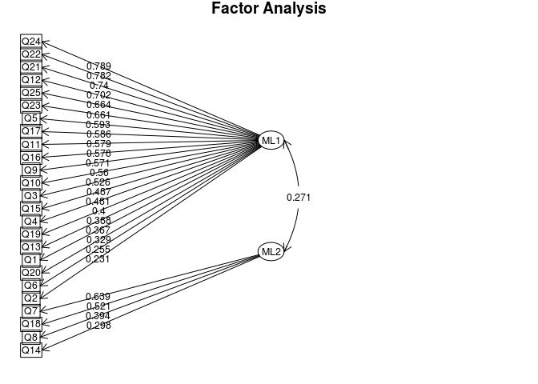

```r
print(fa.1f2o, cut = 0, digits = 3)
```

```
## Factor Analysis using method =  ml
## Call: fa.poly(x = data.1.1, nfactors = 2, rotate = "oblimin", fm = "ml",
##     global = F)
## Standardized loadings (pattern matrix) based upon correlation matrix
##        ML1    ML2     h2    u2  com
## Q1   0.367  0.233 0.2350 0.765 1.69
## Q2   0.231  0.123 0.0837 0.916 1.53
## Q3   0.526 -0.163 0.2568 0.743 1.19
## Q4   0.481  0.176 0.3086 0.691 1.26
## Q5   0.593  0.168 0.4343 0.566 1.16
## Q6   0.255  0.163 0.1139 0.886 1.70
## Q7  -0.043  0.639 0.3955 0.605 1.01
## Q8   0.301  0.394 0.3102 0.690 1.87
## Q9   0.571  0.070 0.3529 0.647 1.03
## Q10  0.560  0.216 0.4258 0.574 1.29
## Q11  0.579  0.164 0.4137 0.586 1.16
## Q12  0.702  0.029 0.5042 0.496 1.00
## Q13  0.388  0.382 0.3772 0.623 2.00
## Q14  0.153  0.298 0.1372 0.863 1.49
## Q15  0.487  0.169 0.3104 0.690 1.24
## Q16  0.578  0.110 0.3803 0.620 1.07
## Q17  0.586  0.245 0.4809 0.519 1.34
## Q18 -0.028  0.521 0.2645 0.735 1.01
## Q19  0.400  0.236 0.2671 0.733 1.62
## Q20  0.329  0.163 0.1638 0.836 1.47
## Q21  0.740 -0.198 0.5080 0.492 1.14
## Q22  0.782 -0.096 0.5805 0.420 1.03
## Q23  0.661  0.051 0.4574 0.543 1.01
## Q24  0.789 -0.143 0.5816 0.418 1.07
## Q25  0.664 -0.171 0.4084 0.592 1.13
##
##                         ML1   ML2
## SS loadings           6.912 1.839
## Proportion Var        0.276 0.074
## Cumulative Var        0.276 0.350
## Proportion Explained  0.790 0.210
## Cumulative Proportion 0.790 1.000
##
##  With factor correlations of
##       ML1   ML2
```

[output cut: 9 more lines]

```
## The root mean square of the residuals (RMSR) is  0.063
## The df corrected root mean square of the residuals is  0.069
##
## The harmonic number of observations is  154 with the empirical chi square  366.567  with prob <  2.59e-06
## The total number of observations was  154  with MLE Chi Square =  403.166  with prob <  3.48e-09
##
## Tucker Lewis Index of factoring reliability =  0.8459
## RMSEA index =  0.0688  and the 90 % confidence intervals are  0.0512 0.0739
## BIC =  -861.109
## Fit based upon off diagonal values = 0.958
## Measures of factor score adequacy
##                                                  ML1   ML2
## Correlation of scores with factors             0.961 0.846
## Multiple R square of scores with factors       0.923 0.716
## Minimum correlation of possible factor scores  0.847 0.431
```

### Factor analysis - secondary

*Item Q2 removed**

```r
# Remove items Q11 and Q20
data.1.1b <- data.1.1[, -c(2)]

# Generate and view polychoric correlation matrix
pc.1b <- polychoric(data.1.1b)
```

```
## The items do not have an equal number of response alternatives, global set to FALSE
```

```r
# Generate internal consistency coefficient alpha
pander(summary(alpha(pc.1b$rho)), style = "rmarkdown", justify = "left", round = 2,
    caption = "CD-RISC: internal consistency after removal of Q2")
```

Reliability analysis  
raw_alpha std.alpha G6(smc) average_r S/N 0.91 0.91 0.93 0.29 9.6

CD-RISC: internal consistency after removal of Q2

| raw_alpha | std.alpha | G6(smc) | average_r | S/N |
| --- | --- | --- | --- | --- |
| 0.91 | 0.91 | 0.93 | 0.29 | 9.58 |

```
## The items do not have an equal number of response alternatives, global set to FALSE
```

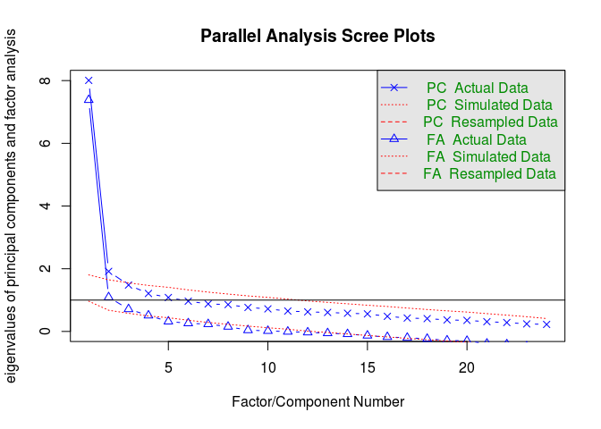

```
## Parallel analysis suggests that the number of factors =  4  and the number of components =  2
```

```r
# Print parallel plots Kaiser dictum: use number of PCA factors above 1 PCA
# line
fa.parallel(data.1.1b, fm = "ml", cor = "poly")
```

```r
# Complete factor analysis - use maximum liklihood (ml) method Start with
# nfactor=3 based on fa.parallel plot Thereafter repeat analysis using 2 and
# 4 factors Test oblique rotation first (Oblimin) Oblimin: 3 factor
fa.1bf3o <- fa.poly(data.1.1b, nfactors = 3, rotate = "oblimin", fm = "ml",
    global = F)
```

```
## The items do not have an equal number of response alternatives, global set to FALSE
```

```r
### Oblimin: 4 factor
fa.1bf4o <- fa.poly(data.1.1b, nfactors = 4, rotate = "oblimin", fm = "ml",
    global = F)
```

```
## The items do not have an equal number of response alternatives, global set to FALSE
```

```r
# Interpret Oblimin: 3 factor
fa.diagram(fa.1bf3o, cut = 0, digits = 3)
```

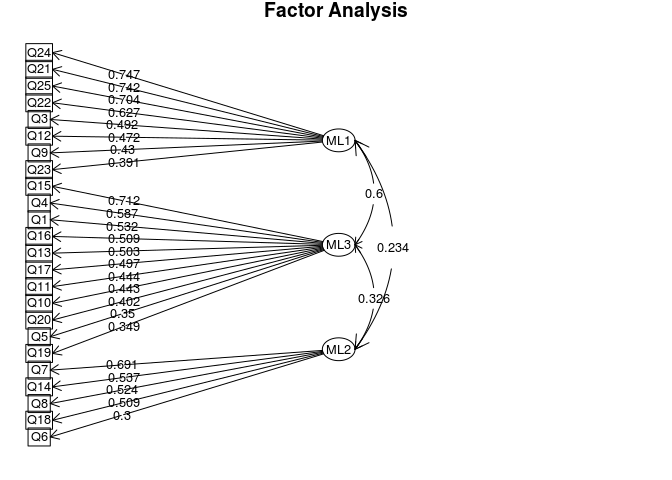

```r
print(fa.1bf3o, cut = 0, digits = 3)
```

```
## Factor Analysis using method =  ml
## Call: fa.poly(x = data.1.1b, nfactors = 3, rotate = "oblimin", fm = "ml",
##     global = F)
## Standardized loadings (pattern matrix) based upon correlation matrix
##        ML1    ML3    ML2    h2    u2  com
## Q1  -0.033  0.532  0.050 0.283 0.717 1.03
## Q3   0.492  0.046 -0.075 0.258 0.742 1.06
## Q4   0.048  0.587 -0.015 0.376 0.624 1.01
## Q5   0.324  0.350  0.136 0.434 0.566 2.29
## Q6   0.276 -0.072  0.300 0.172 0.828 2.11
## Q7  -0.208  0.124  0.691 0.493 0.507 1.25
## Q8   0.213  0.054  0.524 0.407 0.593 1.34
## Q9   0.430  0.168  0.130 0.357 0.643 1.50
## Q10  0.219  0.443  0.131 0.429 0.571 1.66
## Q11  0.244  0.444  0.072 0.421 0.579 1.61
## Q12  0.472  0.299  0.038 0.500 0.500 1.71
## Q13  0.001  0.503  0.226 0.379 0.621 1.39
## Q14  0.286 -0.250  0.537 0.332 0.668 2.00
## Q15 -0.028  0.712 -0.075 0.456 0.544 1.03
## Q16  0.205  0.509 -0.014 0.420 0.580 1.32
## Q17  0.209  0.497  0.142 0.495 0.505 1.52
## Q18 -0.148  0.110  0.509 0.275 0.725 1.27
## Q19  0.127  0.349  0.168 0.268 0.732 1.74
## Q20  0.033  0.402  0.030 0.188 0.812 1.02
## Q21  0.742  0.001 -0.040 0.539 0.461 1.01
## Q22  0.627  0.205 -0.017 0.583 0.417 1.21
## Q23  0.391  0.360  0.022 0.462 0.538 1.99
## Q24  0.747  0.060  0.009 0.619 0.381 1.01
## Q25  0.704 -0.054 -0.002 0.453 0.547 1.01
##
##                         ML1   ML3   ML2
## SS loadings           4.035 3.801 1.762
## Proportion Var        0.168 0.158 0.073
## Cumulative Var        0.168 0.327 0.400
## Proportion Explained  0.420 0.396 0.184
## Cumulative Proportion 0.420 0.816 1.000
##
##  With factor correlations of
##       ML1   ML3   ML2
## ML1 1.000 0.600 0.234
```

[output cut: 9 more lines]

```
## The root mean square of the residuals (RMSR) is  0.05
## The df corrected root mean square of the residuals is  0.058
##
## The harmonic number of observations is  154 with the empirical chi square  215.156  with prob <  0.334
## The total number of observations was  154  with MLE Chi Square =  283.719  with prob <  0.000317
##
## Tucker Lewis Index of factoring reliability =  0.9097
## RMSEA index =  0.0557  and the 90 % confidence intervals are  0.0339 0.0626
## BIC =  -758.93
## Fit based upon off diagonal values = 0.975
## Measures of factor score adequacy
##                                                  ML1   ML3   ML2
## Correlation of scores with factors             0.937 0.923 0.854
## Multiple R square of scores with factors       0.879 0.852 0.729
## Minimum correlation of possible factor scores  0.757 0.703 0.458
```

```r
## Oblimin: 4 factor
fa.diagram(fa.1bf4o, cut = 0, digits = 3)
```

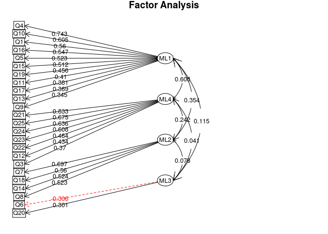

```r
print(fa.1bf4o, cut = 0, digits = 3)
```

```
## Factor Analysis using method =  ml
## Call: fa.poly(x = data.1.1b, nfactors = 4, rotate = "oblimin", fm = "ml",
##     global = F)
## Standardized loadings (pattern matrix) based upon correlation matrix
##        ML1    ML4    ML2    ML3    h2    u2  com
## Q1   0.560 -0.087  0.043  0.075 0.294 0.706 1.10
## Q3   0.218  0.370 -0.104 -0.148 0.271 0.729 2.19
## Q4   0.743 -0.105 -0.048 -0.007 0.447 0.553 1.05
## Q5   0.523  0.167  0.123 -0.119 0.475 0.525 1.44
## Q6   0.174  0.089  0.267 -0.306 0.239 0.761 2.78
## Q7   0.054 -0.180  0.697  0.033 0.480 0.520 1.15
## Q8   0.100  0.158  0.523 -0.083 0.401 0.599 1.32
## Q9   0.345  0.289  0.107 -0.166 0.383 0.617 2.65
## Q10  0.605  0.064  0.109 -0.064 0.473 0.527 1.11
## Q11  0.410  0.242  0.093  0.123 0.425 0.575 1.96
## Q12  0.330  0.434  0.050  0.008 0.498 0.502 1.90
## Q13  0.369  0.057  0.268  0.215 0.389 0.611 2.56
## Q14 -0.141  0.204  0.524 -0.187 0.323 0.677 1.75
## Q15  0.512  0.084 -0.031  0.355 0.479 0.521 1.86
## Q16  0.547  0.144 -0.009  0.046 0.420 0.580 1.15
## Q17  0.381  0.262  0.181  0.215 0.515 0.485 2.96
## Q18 -0.048 -0.060  0.560  0.129 0.314 0.686 1.14
## Q19  0.456  0.019  0.155 -0.052 0.291 0.709 1.26
## Q20  0.197  0.163  0.081  0.301 0.241 0.759 2.53
## Q21 -0.080  0.833 -0.011  0.049 0.621 0.379 1.03
## Q22  0.419  0.464 -0.045 -0.181 0.615 0.385 2.31
## Q23  0.078  0.608  0.090  0.377 0.646 0.354 1.77
## Q24  0.203  0.636  0.003 -0.118 0.606 0.394 1.28
## Q25 -0.001  0.675  0.010 -0.069 0.458 0.542 1.02
##
##                         ML1   ML4   ML2   ML3
## SS loadings           4.123 3.561 1.843 0.775
## Proportion Var        0.172 0.148 0.077 0.032
## Cumulative Var        0.172 0.320 0.397 0.429
## Proportion Explained  0.400 0.346 0.179 0.075
## Cumulative Proportion 0.400 0.746 0.925 1.000
##
##  With factor correlations of
##       ML1   ML4   ML2   ML3
## ML1 1.000 0.608 0.354 0.115
```

[output cut: 10 more lines]

```
## The root mean square of the residuals (RMSR) is  0.043
## The df corrected root mean square of the residuals is  0.053
##
## The harmonic number of observations is  154 with the empirical chi square  159.56  with prob <  0.92
## The total number of observations was  154  with MLE Chi Square =  233.324  with prob <  0.0106
##
## Tucker Lewis Index of factoring reliability =  0.9377
## RMSEA index =  0.0483  and the 90 % confidence intervals are  0.0208 0.0562
## BIC =  -703.549
## Fit based upon off diagonal values = 0.981
## Measures of factor score adequacy
##                                                  ML1   ML4   ML2   ML3
## Correlation of scores with factors             0.931 0.935 0.860 0.768
## Multiple R square of scores with factors       0.867 0.875 0.739 0.590
## Minimum correlation of possible factor scores  0.735 0.750 0.478 0.179
```

## Resilience Scale

### Code key

| Label | Key |
| --- | --- |
| Q1 | When I make plans, I follow through with them |
| Q2 | I usually manage one way or another |
| Q3 | I am able to depend on myself more than anyone else |
| Q4 | Keeping interested in things is important to me |
| Q5 | I can be on my own if I have to |
| Q6 | I feel proud that I have accomplished things in life |
| Q7 | I usually take things in my stride |
| Q8 | I am friends with myself |
| Q9 | I feel that I can handle many things at a time |
| Q10 | I am determined |
| Q11 | I seldom wonder what the point of it all is |
| Q12 | I take things one day at a time |
| Q13 | I can get through difficult times because I have experienced difficulty before |
| Q14 | I have self-discipline |
| Q15 | I keep interested in things |
| Q16 | I can usually find something to laugh about |
| Q17 | My belief in myself gets me through hard times |
| Q18 | In an emergency, I am someone people can general rely on |
| Q19 | I can usually look at a situation in a number of ways |
| Q20 | Sometimes I make myself do things whether I want to or not |
| Q21 | My life has meaning |
| Q22 | I do not dwell on things I cannot do anything about |
| Q23 | When I am in a difficult situation, I can usually find my way out of it |
| Q24 | I have enough energy to do what I have to do |
| Q25 | It is OK if there are people who do not like me |

### Import data

```r
# Read csv
data.2 <- read.csv("resilience.scale.csv", header = T)
```

### Inspect and clean data

```r
# Convert to dplyr object
data.2 <- tbl_df(data.2)
# Inspect the data
head(data.2)
```

```
## Source: local data frame [6 x 26]
##
##   ID Q1 Q2 Q3 Q4 Q5 Q6 Q7 Q8 Q9 Q10 Q11 Q12 Q13 Q14 Q15 Q16 Q17 Q18 Q19
## 1  1  6  6  6  7  7  7  4  6  2   6   7   6   6   7   6   7   7   7   6
## 2  2  5  4  6  6  3  6  6  6  3   6   4   5   4   6   6   5   5   6   5
## 3  3  7  7  7  7  4  7  5  7  6   7   7   7   7   7   7   7   7   7   7
## 4  4  4  6  5  7  7  5  2  7  4   7   1   7   7   7   5   6   7   5   6
## 5  5  7  6  7  7  7  7  6  7  6   7   3   6   7   7   7   6   7   7   7
## 6  6  6  2  2  1  1  4  3  4  1   5   2   5   3   2   1   6   4   2   5
## Variables not shown: Q20 (int), Q21 (int), Q22 (int), Q23 (int), Q24
##   (int), Q25 (int)
```

```r
tail(data.2)
```

```
## Source: local data frame [6 x 26]
##
##    ID Q1 Q2 Q3 Q4 Q5 Q6 Q7 Q8 Q9 Q10 Q11 Q12 Q13 Q14 Q15 Q16 Q17 Q18 Q19
## 1 191  3  5  6  7  5  5  4  6  6   7   6   4   6   6   7   7   7   5   4
## 2 193  4  5  5  6  4  7  7  7  7   7   7   7   7   7   7   7   7   7   7
## 3 194  4  5  6  7  7  7  7  7  1   5   4   4   5   5   6   7   6   5   7
## 4 195  5  3  4  5  1  6  5  4  1   4   3   5   5   6   4   6   5   6   5
## 5 196  4  7  7  7  7  7  4  7  7   7   7   1   7   7   6   6   7   7   5
## 6 197  5  6  6  7  7  7  6  6  6   6   6   6   7   6   6   6   7   6   6
## Variables not shown: Q20 (int), Q21 (int), Q22 (int), Q23 (int), Q24
##   (int), Q25 (int)
```

```r
str(data.2)
```

```
## Classes 'tbl_df', 'tbl' and 'data.frame':    151 obs. of  26 variables:
##  $ ID : int  1 2 3 4 5 6 7 8 9 10 ...
##  $ Q1 : int  6 5 7 4 7 6 5 5 7 6 ...
##  $ Q2 : int  6 4 7 6 6 2 5 4 6 7 ...
##  $ Q3 : int  6 6 7 5 7 2 4 3 7 7 ...
##  $ Q4 : int  7 6 7 7 7 1 5 4 7 7 ...
##  $ Q5 : int  7 3 4 7 7 1 4 3 7 6 ...
##  $ Q6 : int  7 6 7 5 7 4 6 5 6 7 ...
##  $ Q7 : int  4 6 5 2 6 3 7 2 7 7 ...
##  $ Q8 : int  6 6 7 7 7 4 7 6 7 7 ...
##  $ Q9 : int  2 3 6 4 6 1 4 4 5 7 ...
##  $ Q10: int  6 6 7 7 7 5 6 6 7 7 ...
##  $ Q11: int  7 4 7 1 3 2 7 5 6 7 ...
##  $ Q12: int  6 5 7 7 6 5 7 7 7 7 ...
##  $ Q13: int  6 4 7 7 7 3 7 6 7 7 ...
##  $ Q14: int  7 6 7 7 7 2 7 5 7 7 ...
##  $ Q15: int  6 6 7 5 7 1 5 6 6 7 ...
##  $ Q16: int  7 5 7 6 6 6 4 6 7 7 ...
##  $ Q17: int  7 5 7 7 7 4 4 5 6 7 ...
##  $ Q18: int  7 6 7 5 7 2 6 3 7 7 ...
##  $ Q19: int  6 5 7 6 7 5 7 6 7 7 ...
##  $ Q20: int  6 3 1 1 6 3 6 7 5 7 ...
##  $ Q21: int  7 6 7 7 7 2 7 2 7 7 ...
##  $ Q22: int  6 6 7 1 7 4 7 5 7 7 ...
##  $ Q23: int  7 4 7 5 7 4 6 4 7 7 ...
##  $ Q24: int  7 5 7 7 7 2 4 5 5 7 ...
##  $ Q25: int  3 1 1 1 7 1 5 1 7 7 ...
```

```r
# Convert data classes as nessesary
data.2$ID <- factor(data.2$ID)
str(data.2$ID)
```

```
##  Factor w/ 151 levels "1","2","3","4",..: 1 2 3 4 5 6 7 8 9 10 ...
```

### Internal consistency

**Use polychoric correlation matrix throughout because data are ordinal integers, and therefore Pearson’s correlation matrix does not apply**

```r
# Remove ID column
data.2.1 <- data.2[, -1]

# Look at the data
kable(describe(data.2.1))
```

|  | vars | n | mean | sd | median | trimmed | mad | min | max | range | skew | kurtosis | se |
| --- | --- | --- | --- | --- | --- | --- | --- | --- | --- | --- | --- | --- | --- |
| Q1 | 1 | 151 | 5.218543 | 1.4231141 | 5 | 5.347107 | 1.4826 | 1 | 7 | 6 | -0.5508833 | -0.2468192 | 0.1158114 |
| Q2 | 2 | 151 | 5.403974 | 1.3524240 | 6 | 5.545454 | 1.4826 | 2 | 7 | 5 | -0.7053262 | -0.0859676 | 0.1100587 |
| Q3 | 3 | 151 | 6.086093 | 1.2486814 | 7 | 6.314050 | 0.0000 | 1 | 7 | 6 | -1.6514282 | 2.8724809 | 0.1016163 |
| Q4 | 4 | 151 | 6.105960 | 1.1024356 | 6 | 6.280992 | 1.4826 | 1 | 7 | 6 | -1.3944850 | 2.3948120 | 0.0897149 |
| Q5 | 5 | 151 | 4.860927 | 2.2182267 | 6 | 5.074380 | 1.4826 | 1 | 7 | 6 | -0.6119941 | -1.1295753 | 0.1805167 |
| Q6 | 6 | 151 | 6.258278 | 1.0860545 | 7 | 6.462810 | 0.0000 | 3 | 7 | 4 | -1.3580418 | 0.9551860 | 0.0883819 |
| Q7 | 7 | 151 | 5.523179 | 1.6606603 | 6 | 5.768595 | 1.4826 | 1 | 7 | 6 | -0.9860438 | -0.0086460 | 0.1351426 |
| Q8 | 8 | 151 | 6.205298 | 1.2770689 | 7 | 6.504132 | 0.0000 | 2 | 7 | 5 | -1.7964297 | 2.4497429 | 0.1039264 |
| Q9 | 9 | 151 | 5.000000 | 1.8220867 | 5 | 5.214876 | 1.4826 | 1 | 7 | 6 | -0.7882218 | -0.3792080 | 0.1482793 |
| Q10 | 10 | 151 | 6.423841 | 0.8751159 | 7 | 6.586777 | 0.0000 | 3 | 7 | 4 | -1.5767266 | 2.2374051 | 0.0712159 |
| Q11 | 11 | 151 | 4.099338 | 2.2113494 | 4 | 4.123967 | 2.9652 | 1 | 7 | 6 | -0.0145412 | -1.5496416 | 0.1799571 |
| Q12 | 12 | 151 | 5.642384 | 1.3968745 | 6 | 5.834711 | 1.4826 | 1 | 7 | 6 | -0.9988057 | 0.5290205 | 0.1136760 |
| Q13 | 13 | 151 | 6.516556 | 0.8629740 | 7 | 6.727273 | 0.0000 | 3 | 7 | 4 | -2.0601326 | 4.0628903 | 0.0702278 |
| Q14 | 14 | 151 | 6.562914 | 0.7445460 | 7 | 6.710744 | 0.0000 | 2 | 7 | 5 | -2.3804343 | 8.7190451 | 0.0605903 |
| Q15 | 15 | 151 | 6.132450 | 1.3149170 | 7 | 6.413223 | 0.0000 | 1 | 7 | 6 | -2.0780871 | 4.7105613 | 0.1070064 |
| Q16 | 16 | 151 | 6.026490 | 1.2433665 | 6 | 6.256198 | 1.4826 | 1 | 7 | 6 | -1.6621155 | 3.1019936 | 0.1011837 |
| Q17 | 17 | 151 | 6.450331 | 0.9358685 | 7 | 6.644628 | 0.0000 | 3 | 7 | 4 | -1.6746989 | 2.0530074 | 0.0761599 |
| Q18 | 18 | 151 | 6.192053 | 1.2946826 | 7 | 6.487603 | 0.0000 | 1 | 7 | 6 | -1.9497943 | 3.5243005 | 0.1053598 |
| Q19 | 19 | 151 | 6.092715 | 1.0220958 | 6 | 6.231405 | 1.4826 | 2 | 7 | 5 | -1.1145808 | 1.1539711 | 0.0831770 |
| Q20 | 20 | 151 | 5.086093 | 1.8108576 | 6 | 5.305785 | 1.4826 | 1 | 7 | 6 | -0.7897476 | -0.4386284 | 0.1473655 |
| Q21 | 21 | 151 | 6.304636 | 1.1831786 | 7 | 6.586777 | 0.0000 | 2 | 7 | 5 | -1.8479097 | 2.6668798 | 0.0962857 |
| Q22 | 22 | 151 | 6.019868 | 1.4718252 | 7 | 6.330578 | 0.0000 | 1 | 7 | 6 | -1.7787506 | 2.8033864 | 0.1197754 |
| Q23 | 23 | 151 | 6.185430 | 1.0795306 | 7 | 6.363636 | 0.0000 | 1 | 7 | 6 | -1.5066012 | 2.8321696 | 0.0878510 |
| Q24 | 24 | 151 | 5.940397 | 1.4479033 | 7 | 6.214876 | 0.0000 | 1 | 7 | 6 | -1.4284759 | 1.3701123 | 0.1178287 |
| Q25 | 25 | 151 | 5.258278 | 2.2104708 | 6 | 5.570248 | 1.4826 | 1 | 7 | 6 | -0.9255534 | -0.6953528 | 0.1798856 |

```r
# Generate and view polychoric correlation matrix
pc.2 <- polychoric(data.2.1)
```

```
## The items do not have an equal number of response alternatives, global set to FALSE
```

```r
# Generate internal consistency coefficient alpha
pander(summary(alpha(pc.2$rho)), style = "rmarkdown", justify = "left", round = 2,
    caption = "CD-RISC: internal consistency")
```

Reliability analysis  
raw_alpha std.alpha G6(smc) average_r S/N 0.93 0.93 0.94 0.34 13

| raw_alpha | std.alpha | G6(smc) | average_r | S/N |
| --- | --- | --- | --- | --- |
| 0.93 | 0.93 | 0.94 | 0.34 | 12.78 |

### Factor analysis

```
## The items do not have an equal number of response alternatives, global set to FALSE
```

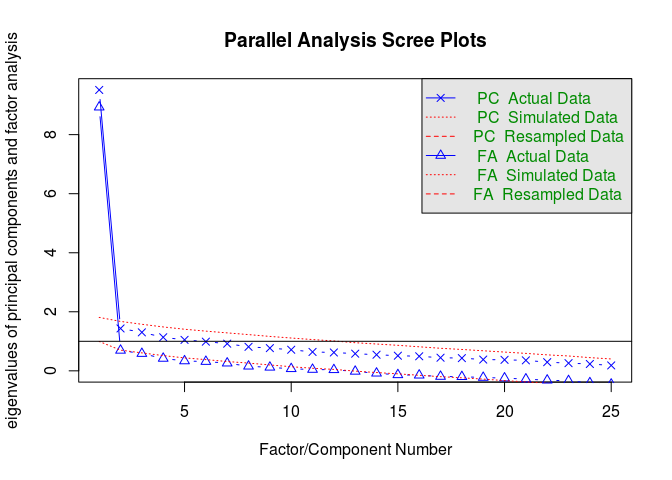

```
## Parallel analysis suggests that the number of factors =  1  and the number of components =  1
```

```r
# Print parallel plots Kaiser dictum: use number of PCA factors above 1 PCA
# line
fa.parallel(data.2.1, fm = "ml", cor = "poly")
```

```r
# Complete factor analysis - use maximum liklihood (ml) method Start with
# nfactor=1 based on fa.parallel plot Thereafter repeat analysis using 2 and
# 3 factors Test oblique rotation first (Oblimin) Oblimin: 1 factor
fa.2f1o <- fa.poly(data.2.1, nfactors = 1, rotate = "oblimin", fm = "ml", global = F)
```

```
## The items do not have an equal number of response alternatives, global set to FALSE
```

```r
### Oblimin: 2 factor
fa.2f2o <- fa.poly(data.2.1, nfactors = 2, rotate = "oblimin", fm = "ml", global = F)
```

```
## The items do not have an equal number of response alternatives, global set to FALSE
```

```r
### Oblimin: 3 factor
fa.2f3o <- fa.poly(data.2.1, nfactors = 3, rotate = "oblimin", fm = "ml", global = F)
```

```
## The items do not have an equal number of response alternatives, global set to FALSE
```

```r
# Interpret Oblimin: 1 factor
fa.diagram(fa.2f1o, cut = 0, digits = 3, labels = as.list(rs.names))
```

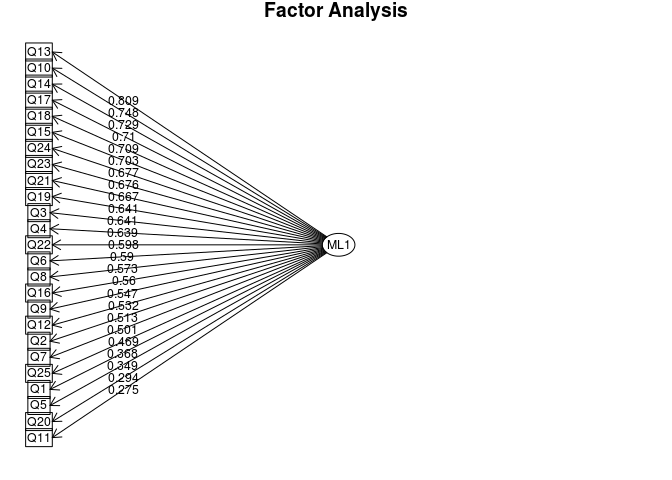

```r
print(fa.2f1o, cut = 0, digits = 3)
```

```
## Factor Analysis using method =  ml
## Call: fa.poly(x = data.2.1, nfactors = 1, rotate = "oblimin", fm = "ml",
##     global = F)
## Standardized loadings (pattern matrix) based upon correlation matrix
##       ML1     h2    u2 com
## Q1  0.368 0.1355 0.865   1
## Q2  0.513 0.2628 0.737   1
## Q3  0.641 0.4113 0.589   1
## Q4  0.639 0.4084 0.592   1
## Q5  0.349 0.1217 0.878   1
## Q6  0.590 0.3484 0.652   1
## Q7  0.501 0.2514 0.749   1
## Q8  0.573 0.3283 0.672   1
## Q9  0.547 0.2997 0.700   1
## Q10 0.748 0.5592 0.441   1
## Q11 0.275 0.0757 0.924   1
## Q12 0.532 0.2833 0.717   1
## Q13 0.809 0.6551 0.345   1
## Q14 0.729 0.5317 0.468   1
## Q15 0.703 0.4944 0.506   1
## Q16 0.560 0.3135 0.687   1
## Q17 0.710 0.5036 0.496   1
## Q18 0.709 0.5028 0.497   1
## Q19 0.641 0.4114 0.589   1
## Q20 0.294 0.0862 0.914   1
## Q21 0.667 0.4454 0.555   1
## Q22 0.598 0.3577 0.642   1
## Q23 0.676 0.4568 0.543   1
## Q24 0.677 0.4577 0.542   1
## Q25 0.469 0.2204 0.780   1
##
##                  ML1
## SS loadings    8.922
## Proportion Var 0.357
##
## Mean item complexity =  1
## Test of the hypothesis that 1 factor is sufficient.
##
## The degrees of freedom for the null model are  300  and the objective function was  11.64 with Chi Square of  1639.367
## The degrees of freedom for the model are 275  and the objective function was  2.743
##
## The root mean square of the residuals (RMSR) is  0.061
## The df corrected root mean square of the residuals is  0.064
##
## The harmonic number of observations is  151 with the empirical chi square  337.587  with prob <  0.00591
## The total number of observations was  151  with MLE Chi Square =  384.453  with prob <  1.4e-05
##
## Tucker Lewis Index of factoring reliability =  0.9103
## RMSEA index =  0.0575  and the 90 % confidence intervals are  0.0386 0.0631
## BIC =  -995.299
## Fit based upon off diagonal values = 0.971
## Measures of factor score adequacy
##                                                  ML1
## Correlation of scores with factors             0.970
## Multiple R square of scores with factors       0.942
## Minimum correlation of possible factor scores  0.884
```

```r
## Oblimin: 2 factor
fa.diagram(fa.2f2o, cut = 0, digits = 3, labels = as.list(rs.names))
```

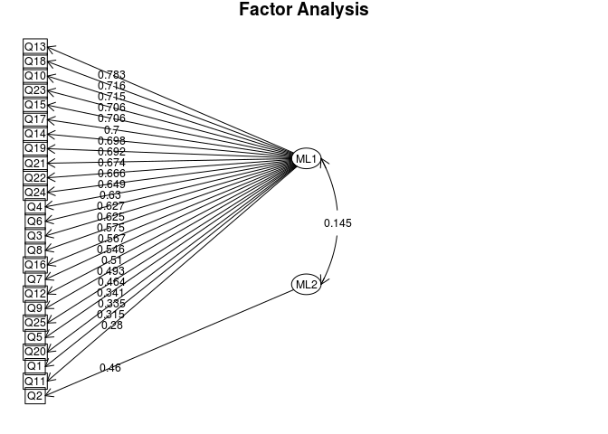

```r
print(fa.2f2o, cut = 0, digits = 3)
```

```
## Factor Analysis using method =  ml
## Call: fa.poly(x = data.2.1, nfactors = 2, rotate = "oblimin", fm = "ml",
##     global = F)
## Standardized loadings (pattern matrix) based upon correlation matrix
##       ML1    ML2    h2    u2  com
## Q1  0.315  0.296 0.214 0.786 1.99
## Q2  0.432  0.460 0.456 0.544 1.99
## Q3  0.625  0.085 0.413 0.587 1.04
## Q4  0.630  0.041 0.406 0.594 1.01
## Q5  0.341  0.042 0.122 0.878 1.03
## Q6  0.627 -0.172 0.392 0.608 1.15
## Q7  0.546 -0.214 0.310 0.690 1.30
## Q8  0.575 -0.024 0.327 0.673 1.00
## Q9  0.493  0.298 0.374 0.626 1.64
## Q10 0.715  0.182 0.582 0.418 1.13
## Q11 0.280 -0.023 0.077 0.923 1.01
## Q12 0.510  0.123 0.293 0.707 1.11
## Q13 0.783  0.145 0.667 0.333 1.07
## Q14 0.698  0.158 0.545 0.455 1.10
## Q15 0.706 -0.023 0.494 0.506 1.00
## Q16 0.567 -0.039 0.316 0.684 1.01
## Q17 0.700  0.043 0.501 0.499 1.01
## Q18 0.716 -0.036 0.507 0.493 1.01
## Q19 0.692 -0.230 0.486 0.514 1.22
## Q20 0.335 -0.206 0.135 0.865 1.66
## Q21 0.674 -0.029 0.450 0.550 1.00
## Q22 0.666 -0.308 0.479 0.521 1.41
## Q23 0.706 -0.141 0.490 0.510 1.08
## Q24 0.649  0.148 0.471 0.529 1.10
## Q25 0.464  0.029 0.220 0.780 1.01
##
##                         ML1   ML2
## SS loadings           8.887 0.841
## Proportion Var        0.355 0.034
## Cumulative Var        0.355 0.389
## Proportion Explained  0.914 0.086
## Cumulative Proportion 0.914 1.000
##
##  With factor correlations of
##       ML1   ML2
```

[output cut: 9 more lines]

```
## The root mean square of the residuals (RMSR) is  0.053
## The df corrected root mean square of the residuals is  0.058
##
## The harmonic number of observations is  151 with the empirical chi square  257.883  with prob <  0.369
## The total number of observations was  151  with MLE Chi Square =  327.756  with prob <  0.000797
##
## Tucker Lewis Index of factoring reliability =  0.9307
## RMSEA index =  0.0519  and the 90 % confidence intervals are  0.0299 0.058
## BIC =  -931.581
## Fit based upon off diagonal values = 0.978
## Measures of factor score adequacy
##                                                  ML1   ML2
## Correlation of scores with factors             0.971 0.767
## Multiple R square of scores with factors       0.943 0.588
## Minimum correlation of possible factor scores  0.887 0.177
```

```r
## Oblimin: 3 factor
fa.diagram(fa.2f3o, cut = 0, digits = 3, labels = as.list(rs.names))
```

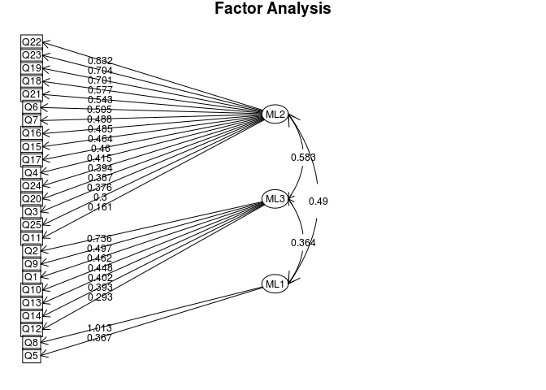

```r
print(fa.2f3o, cut = 0, digits = 3)
```

```
## Factor Analysis using method =  ml
## Call: fa.poly(x = data.2.1, nfactors = 3, rotate = "oblimin", fm = "ml",
##     global = F)
##
##  Warning: A Heywood case was detected.
## Standardized loadings (pattern matrix) based upon correlation matrix
##        ML2    ML3    ML1     h2    u2  com
## Q1   0.010  0.462 -0.005 0.2170 0.783 1.00
## Q2  -0.036  0.736 -0.051 0.4892 0.511 1.01
## Q3   0.376  0.290  0.090 0.4140 0.586 2.01
## Q4   0.415  0.238  0.092 0.4056 0.594 1.71
## Q5   0.017  0.127  0.367 0.1942 0.806 1.24
## Q6   0.505 -0.055  0.264 0.4158 0.584 1.54
## Q7   0.488 -0.109  0.211 0.3174 0.683 1.48
## Q8  -0.014 -0.027  1.013 0.9950 0.005 1.00
## Q9  -0.007  0.497  0.258 0.4011 0.599 1.50
## Q10  0.406  0.448  0.019 0.5919 0.408 1.98
## Q11  0.161  0.056  0.128 0.0812 0.919 2.16
## Q12  0.180  0.293  0.209 0.3040 0.696 2.54
## Q13  0.399  0.402  0.181 0.6656 0.334 2.38
## Q14  0.348  0.393  0.137 0.5408 0.459 2.23
## Q15  0.464  0.179  0.192 0.4929 0.507 1.66
## Q16  0.485  0.152 -0.030 0.3277 0.672 1.20
## Q17  0.460  0.256  0.119 0.5032 0.497 1.72
## Q18  0.577  0.181  0.036 0.5142 0.486 1.20
## Q19  0.701 -0.059  0.054 0.4844 0.516 1.03
## Q20  0.387 -0.119  0.035 0.1217 0.878 1.20
## Q21  0.543  0.174  0.035 0.4601 0.540 1.21
## Q22  0.832 -0.161 -0.075 0.5152 0.485 1.09
## Q23  0.704  0.064 -0.052 0.5164 0.484 1.03
## Q24  0.394  0.389 -0.004 0.4826 0.517 2.00
## Q25  0.300  0.179  0.070 0.2188 0.781 1.76
##
##                         ML2   ML3   ML1
## SS loadings           5.655 3.014 2.001
## Proportion Var        0.226 0.121 0.080
## Cumulative Var        0.226 0.347 0.427
## Proportion Explained  0.530 0.282 0.188
## Cumulative Proportion 0.530 0.812 1.000
##
```

[output cut: 12 more lines]

```
## The root mean square of the residuals (RMSR) is  0.047
## The df corrected root mean square of the residuals is  0.054
##
## The harmonic number of observations is  151 with the empirical chi square  201.804  with prob <  0.894
## The total number of observations was  151  with MLE Chi Square =  272.639  with prob <  0.0228
##
## Tucker Lewis Index of factoring reliability =  0.9554
## RMSEA index =  0.0441  and the 90 % confidence intervals are  0.0145 0.0512
## BIC =  -871.3
## Fit based upon off diagonal values = 0.983
## Measures of factor score adequacy
##                                                  ML2   ML3   ML1
## Correlation of scores with factors             0.950 0.906 0.998
## Multiple R square of scores with factors       0.903 0.820 0.995
## Minimum correlation of possible factor scores  0.805 0.640 0.990
```

### Outcome of initial factor analysis

The 2-factor structure produced the most parsimonious outcome based on the empirical $\chi$<sup>2</sup> goodness of fit test, but the 1-factor solution was recommended by the parallel plot. On the 1-factor solution, two items (Q11: “I seldom wonder what the point of it all is”, and Q20: “Sometimes I make myself do things whether I want to or not”) had factor loadings < 0.3, and were removed and the data reanalysed with a 1-factor structure (as per the original and revised parallel plots), and a 2-factor structure (based on the empirical $\chi$<sup>2</sup> goodness of fit test on the original 2-factor solution).On the 2-factor solution, only one item (Q11: “I seldom wonder what the point of it all is”) had factor loadings < 0.3, and was removed and the data reanalysed with a 1-factor structure (as per the original and revised parallel plots), and a 2-factor structure (based on the empirical $\chi$<sup>2</sup> goodness of fit test on the original 2-factor solution).

### Factor analysis - secondary

*Item Q11 and Q20 removed based on the outcome of the original 1-factor solution**

```r
# Remove items Q11 and Q20
data.2.1b1 <- data.2.1[, -c(11, 20)]

# Generate and view polychoric correlation matrix
pc.2b1 <- polychoric(data.2.1b1)
```

```
## The items do not have an equal number of response alternatives, global set to FALSE
```

```r
# Generate internal consistency coefficient alpha
pander(summary(alpha(pc.2b1$rho)), style = "rmarkdown", justify = "left", round = 2,
    caption = "CD-RISC: internal consistency after removal fo Q11 and Q20")
```

Reliability analysis  
raw_alpha std.alpha G6(smc) average_r S/N 0.93 0.93 0.94 0.37 13

| raw_alpha | std.alpha | G6(smc) | average_r | S/N |
| --- | --- | --- | --- | --- |
| 0.93 | 0.93 | 0.94 | 0.37 | 13.37 |

```
## The items do not have an equal number of response alternatives, global set to FALSE
```

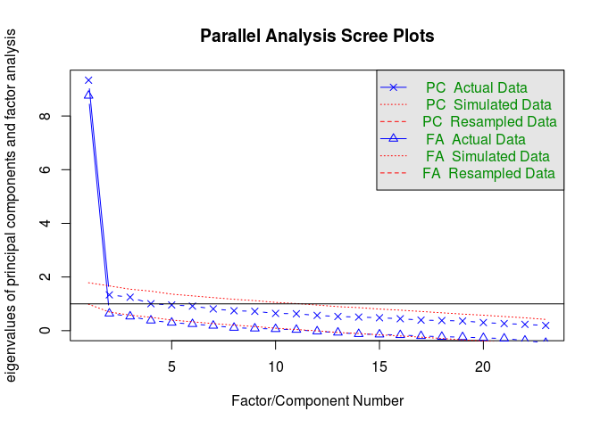

```
## Parallel analysis suggests that the number of factors =  1  and the number of components =  1
```

```r
# Print parallel plots Kaiser dictum: use number of PCA factors above 1 PCA
# line
fa.parallel(data.2.1b1, fm = "ml", cor = "poly")
```

```r
# Complete factor analysis - use maximum liklihood (ml) method Start with
# nfactor=3 based on fa.parallel plot Thereafter repeat analysis using 2 and
# 4 factors Test oblique rotation first (Oblimin) Oblimin: 1 factor
fa.2b1f1o <- fa.poly(data.2.1b1, nfactors = 1, rotate = "oblimin", fm = "ml",
    global = F)
```

```
## The items do not have an equal number of response alternatives, global set to FALSE
```

```r
### Oblimin: 2 factor
fa.2b1f2o <- fa.poly(data.2.1b1, nfactors = 2, rotate = "oblimin", fm = "ml",
    global = F)
```

```
## The items do not have an equal number of response alternatives, global set to FALSE
```

```r
# Interpret Oblimin: 1 factor
fa.diagram(fa.2b1f1o, cut = 0, digits = 3)
```

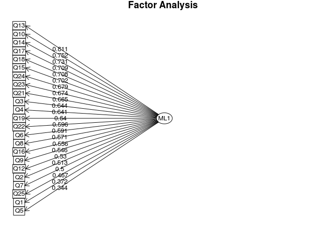

```r
print(fa.2b1f1o, cut = 0, digits = 3)
```

```
## Factor Analysis using method =  ml
## Call: fa.poly(x = data.2.1b1, nfactors = 1, rotate = "oblimin", fm = "ml",
##     global = F)
## Standardized loadings (pattern matrix) based upon correlation matrix
##       ML1    h2    u2 com
## Q1  0.372 0.139 0.861   1
## Q2  0.513 0.263 0.737   1
## Q3  0.644 0.414 0.586   1
## Q4  0.641 0.411 0.589   1
## Q5  0.344 0.118 0.882   1
## Q6  0.591 0.349 0.651   1
## Q7  0.500 0.250 0.750   1
## Q8  0.571 0.326 0.674   1
## Q9  0.546 0.298 0.702   1
## Q10 0.752 0.566 0.434   1
## Q12 0.530 0.281 0.719   1
## Q13 0.811 0.658 0.342   1
## Q14 0.731 0.535 0.465   1
## Q15 0.702 0.493 0.507   1
## Q16 0.556 0.310 0.690   1
## Q17 0.709 0.502 0.498   1
## Q18 0.708 0.502 0.498   1
## Q19 0.640 0.410 0.590   1
## Q21 0.665 0.443 0.557   1
## Q22 0.596 0.355 0.645   1
## Q23 0.674 0.454 0.546   1
## Q24 0.679 0.461 0.539   1
## Q25 0.467 0.218 0.782   1
##
##                  ML1
## SS loadings    8.755
## Proportion Var 0.381
##
## Mean item complexity =  1
## Test of the hypothesis that 1 factor is sufficient.
##
## The degrees of freedom for the null model are  253  and the objective function was  11.091 with Chi Square of  1569.331
## The degrees of freedom for the model are 230  and the objective function was  2.35
##
## The root mean square of the residuals (RMSR) is  0.059
## The df corrected root mean square of the residuals is  0.062
##
## The harmonic number of observations is  151 with the empirical chi square  267.021  with prob <  0.0473
## The total number of observations was  151  with MLE Chi Square =  330.944  with prob <  1.43e-05
##
## Tucker Lewis Index of factoring reliability =  0.9152
## RMSEA index =  0.0596  and the 90 % confidence intervals are  0.0404 0.0664
## BIC =  -823.03
## Fit based upon off diagonal values = 0.976
## Measures of factor score adequacy
##                                                  ML1
## Correlation of scores with factors             0.970
## Multiple R square of scores with factors       0.941
## Minimum correlation of possible factor scores  0.883
```

```r
## Oblimin: 2 factor
fa.diagram(fa.2b1f2o, cut = 0, digits = 3)
```

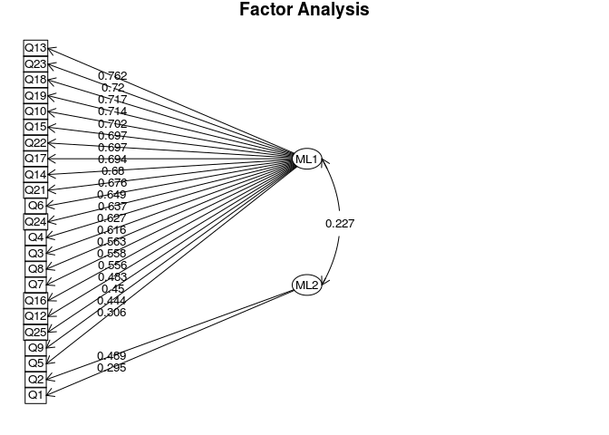

```r
print(fa.2b1f2o, cut = 0, digits = 3)
```

```
## Factor Analysis using method =  ml
## Call: fa.poly(x = data.2.1b1, nfactors = 2, rotate = "oblimin", fm = "ml",
##     global = F)
## Standardized loadings (pattern matrix) based upon correlation matrix
##       ML1    ML2    h2    u2  com
## Q1  0.287  0.295 0.208 0.792 2.00
## Q2  0.373  0.489 0.461 0.539 1.87
## Q3  0.616  0.094 0.415 0.585 1.05
## Q4  0.627  0.047 0.408 0.592 1.01
## Q5  0.306  0.126 0.127 0.873 1.33
## Q6  0.649 -0.173 0.400 0.600 1.14
## Q7  0.558 -0.177 0.298 0.702 1.20
## Q8  0.563  0.025 0.324 0.676 1.00
## Q9  0.444  0.351 0.391 0.609 1.90
## Q10 0.702  0.172 0.578 0.422 1.12
## Q12 0.483  0.163 0.296 0.704 1.23
## Q13 0.762  0.173 0.670 0.330 1.10
## Q14 0.680  0.170 0.544 0.456 1.12
## Q15 0.697  0.013 0.491 0.509 1.00
## Q16 0.556  0.000 0.310 0.690 1.00
## Q17 0.694  0.051 0.500 0.500 1.01
## Q18 0.717 -0.025 0.507 0.493 1.00
## Q19 0.714 -0.218 0.487 0.513 1.18
## Q21 0.676 -0.024 0.450 0.550 1.00
## Q22 0.697 -0.297 0.479 0.521 1.35
## Q23 0.720 -0.133 0.493 0.507 1.07
## Q24 0.637  0.145 0.469 0.531 1.10
## Q25 0.450  0.061 0.218 0.782 1.04
##
##                         ML1   ML2
## SS loadings           8.581 0.943
## Proportion Var        0.373 0.041
## Cumulative Var        0.373 0.414
## Proportion Explained  0.901 0.099
## Cumulative Proportion 0.901 1.000
##
##  With factor correlations of
##       ML1   ML2
## ML1 1.000 0.227
## ML2 0.227 1.000
##
## Mean item complexity =  1.2
## Test of the hypothesis that 2 factors are sufficient.
##
## The degrees of freedom for the null model are  253  and the objective function was  11.091 with Chi Square of  1569.331
## The degrees of freedom for the model are 208  and the objective function was  1.982
##
## The root mean square of the residuals (RMSR) is  0.051
## The df corrected root mean square of the residuals is  0.056
##
## The harmonic number of observations is  151 with the empirical chi square  195.955  with prob <  0.715
## The total number of observations was  151  with MLE Chi Square =  277.779  with prob <  0.00087
##
## Tucker Lewis Index of factoring reliability =  0.9348
## RMSEA index =  0.0535  and the 90 % confidence intervals are  0.0311 0.0611
## BIC =  -765.815
## Fit based upon off diagonal values = 0.983
## Measures of factor score adequacy
##                                                  ML1   ML2
## Correlation of scores with factors             0.970 0.777
## Multiple R square of scores with factors       0.941 0.604
## Minimum correlation of possible factor scores  0.883 0.207
```

*Only item Q11 removed based on the outcome of the original 2-factor solution**

```
## The items do not have an equal number of response alternatives, global set to FALSE
```

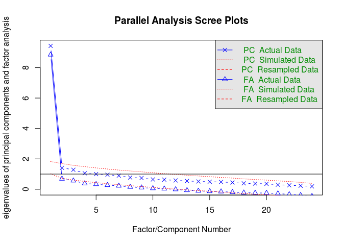

```
## Parallel analysis suggests that the number of factors =  1  and the number of components =  1
```

```r
# Remove items Q11 and Q20
data.2.1b2 <- data.2.1[, -c(11)]

# Print parallel plots Kaiser dictum: use number of PCA factors above 1 PCA
# line
fa.parallel(data.2.1b2, fm = "ml", cor = "poly")
```

```r
# Complete factor analysis - use maximum liklihood (ml) method Start with
# nfactor=3 based on fa.parallel plot Thereafter repeat analysis using 2 and
# 4 factors Test oblique rotation first (Oblimin) Oblimin: 1 factor
fa.2b2f1o <- fa.poly(data.2.1b2, nfactors = 1, rotate = "oblimin", fm = "ml",
    global = F)
```

```
## The items do not have an equal number of response alternatives, global set to FALSE
```

```r
### Oblimin: 2 factor
fa.2b2f2o <- fa.poly(data.2.1b2, nfactors = 2, rotate = "oblimin", fm = "ml",
    global = F)
```

```
## The items do not have an equal number of response alternatives, global set to FALSE
```

```r
# Interpret Oblimin: 1 factor
fa.diagram(fa.2b2f1o, cut = 0, digits = 3)
```

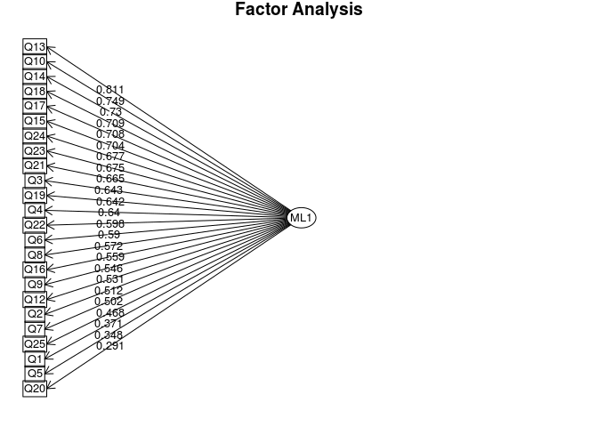

```r
print(fa.2b2f1o, cut = 0, digits = 3)
```

```
## Factor Analysis using method =  ml
## Call: fa.poly(x = data.2.1b2, nfactors = 1, rotate = "oblimin", fm = "ml",
##     global = F)
## Standardized loadings (pattern matrix) based upon correlation matrix
##       ML1     h2    u2 com
## Q1  0.371 0.1374 0.863   1
## Q2  0.512 0.2619 0.738   1
## Q3  0.643 0.4138 0.586   1
## Q4  0.640 0.4100 0.590   1
## Q5  0.348 0.1212 0.879   1
## Q6  0.590 0.3479 0.652   1
## Q7  0.502 0.2524 0.748   1
## Q8  0.572 0.3269 0.673   1
## Q9  0.546 0.2978 0.702   1
## Q10 0.749 0.5612 0.439   1
## Q12 0.531 0.2816 0.718   1
## Q13 0.811 0.6576 0.342   1
## Q14 0.730 0.5326 0.467   1
## Q15 0.704 0.4950 0.505   1
## Q16 0.559 0.3129 0.687   1
## Q17 0.708 0.5014 0.499   1
## Q18 0.709 0.5026 0.497   1
## Q19 0.642 0.4117 0.588   1
## Q20 0.291 0.0849 0.915   1
## Q21 0.665 0.4428 0.557   1
## Q22 0.598 0.3577 0.642   1
## Q23 0.675 0.4552 0.545   1
## Q24 0.677 0.4584 0.542   1
## Q25 0.468 0.2190 0.781   1
##
##                  ML1
## SS loadings    8.844
## Proportion Var 0.368
##
## Mean item complexity =  1
## Test of the hypothesis that 1 factor is sufficient.
##
## The degrees of freedom for the null model are  276  and the objective function was  11.374 with Chi Square of  1605.615
## The degrees of freedom for the model are 252  and the objective function was  2.55
##
## The root mean square of the residuals (RMSR) is  0.061
## The df corrected root mean square of the residuals is  0.063
##
## The harmonic number of observations is  151 with the empirical chi square  306.662  with prob <  0.0105
## The total number of observations was  151  with MLE Chi Square =  358.276  with prob <  1.2e-05
##
## Tucker Lewis Index of factoring reliability =  0.912
## RMSEA index =  0.0588  and the 90 % confidence intervals are  0.0397 0.0649
## BIC =  -906.079
## Fit based upon off diagonal values = 0.973
## Measures of factor score adequacy
##                                                  ML1
## Correlation of scores with factors             0.970
## Multiple R square of scores with factors       0.942
## Minimum correlation of possible factor scores  0.883
```

```r
## Oblimin: 2 factor
fa.diagram(fa.2b2f2o, cut = 0, digits = 3)
```

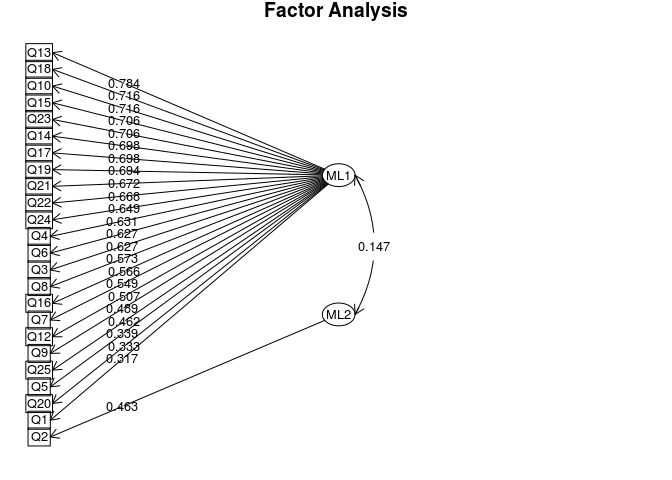

```r
print(fa.2b2f2o, cut = 0, digits = 3)
```

```
## Factor Analysis using method =  ml
## Call: fa.poly(x = data.2.1b2, nfactors = 2, rotate = "oblimin", fm = "ml",
##     global = F)
## Standardized loadings (pattern matrix) based upon correlation matrix
##       ML1    ML2    h2    u2  com
## Q1  0.317  0.291 0.212 0.788 1.99
## Q2  0.429  0.463 0.457 0.543 1.99
## Q3  0.627  0.081 0.415 0.585 1.03
## Q4  0.631  0.038 0.407 0.593 1.01
## Q5  0.339  0.047 0.122 0.878 1.04
## Q6  0.627 -0.171 0.391 0.609 1.15
## Q7  0.549 -0.216 0.313 0.687 1.30
## Q8  0.573 -0.019 0.326 0.674 1.00
## Q9  0.489  0.302 0.374 0.626 1.67
## Q10 0.716  0.179 0.582 0.418 1.12
## Q12 0.507  0.126 0.292 0.708 1.12
## Q13 0.784  0.145 0.669 0.331 1.07
## Q14 0.698  0.158 0.545 0.455 1.10
## Q15 0.706 -0.023 0.495 0.505 1.00
## Q16 0.566 -0.038 0.316 0.684 1.01
## Q17 0.698  0.047 0.499 0.501 1.01
## Q18 0.716 -0.037 0.507 0.493 1.01
## Q19 0.694 -0.232 0.487 0.513 1.22
## Q20 0.333 -0.200 0.131 0.869 1.64
## Q21 0.672 -0.026 0.447 0.553 1.00
## Q22 0.668 -0.309 0.481 0.519 1.41
## Q23 0.706 -0.139 0.488 0.512 1.08
## Q24 0.649  0.148 0.472 0.528 1.10
## Q25 0.462  0.033 0.219 0.781 1.01
##
##                         ML1   ML2
## SS loadings           8.803 0.845
## Proportion Var        0.367 0.035
## Cumulative Var        0.367 0.402
## Proportion Explained  0.912 0.088
## Cumulative Proportion 0.912 1.000
##
##  With factor correlations of
##       ML1   ML2
## ML1 1.000 0.147
```

[output cut: 8 more lines]

```
## The root mean square of the residuals (RMSR) is  0.052
## The df corrected root mean square of the residuals is  0.057
##
## The harmonic number of observations is  151 with the empirical chi square  227.466  with prob <  0.516
## The total number of observations was  151  with MLE Chi Square =  301.703  with prob <  0.000896
##
## Tucker Lewis Index of factoring reliability =  0.9333
## RMSEA index =  0.0525  and the 90 % confidence intervals are  0.0303 0.0594
## BIC =  -847.254
## Fit based upon off diagonal values = 0.98
## Measures of factor score adequacy
##                                                  ML1   ML2
## Correlation of scores with factors             0.971 0.768
## Multiple R square of scores with factors       0.943 0.590
## Minimum correlation of possible factor scores  0.886 0.179
```

References

[1] Bernaards CA, I.Jennrich R. Gradient projection algorithms and software for arbitrary rotation criteria in factor analysis. Educational and Psychological Measurement 2005;65:676–696.

[2] Connor KM, Davidson JR. Development of a new resilience scale: The connor-davidson resilience scale (CD-RISC). Depression and Anxiety 2003;18:76–82. doi:10.1002/da.10113.

[3] Dar’oczi G, Tsegelskyi R. Pander: An r pandoc writer. 2015 Available: http://CRAN.R-project.org/package=pander.

[4] GM W, HM Y. Development and psychometric evaluation of the resilience scale. - pubMed - nCBI. PubMed New and Noteworthy 2015. Available: http://www.ncbi.nlm.nih.gov/pubmed/7850498.

[5] R Core Team. R: A language and environment for statistical computing. Vienna, Austria: R Foundation for Statistical Computing, 2015 Available: https://www.R-project.org/.

[6] Revelle W. Psych: Procedures for psychological, psychometric, and personality research. Evanston, Illinois: Northwestern University, 2015 Available: http://CRAN.R-project.org/package=psych.

[7] Wickham H. Ggplot2: Elegant graphics for data analysis. Springer New York, 2009 Available: http://had.co.nz/ggplot2/book.

[8] Wickham H. Tidyr: Easily tidy data with spread() and gather() functions. 2014 Available: http://CRAN.R-project.org/package=tidyr.

[9] Wickham H, Francois R. Dplyr: A grammar of data manipulation. 2015 Available: http://CRAN.R-project.org/package=dplyr.

[10] Xie Y. Dynamic documents with R and knitr. 2nd ed. Boca Raton, Florida: Chapman; Hall/CRC, 2015 Available: http://yihui.name/knitr/.

[11] Xie Y. Knitr: A comprehensive tool for reproducible research in R. In: Stodden V, Leisch F, Peng RD, editors. Implementing reproducible computational research. Chapman; Hall/CRC, 2014. Available: http://www.crcpress.com/product/isbn/9781466561595.

[12] Xie Y. Knitr: A general-purpose package for dynamic report generation in r. 2015 Available: http://yihui.name/knitr/.